# SEM

Joshua McCarthy

02/07/2020

```r
library(tidyverse)
library(lubridate)
library(visdat)
```

# Intent

## Research Questions

1. Assess the validity of implied structure of of understanding in the previous research undertaken
2. Assess the age, chronic disease, death sub structure
3. Assess alternative structures for improvement

## Outcomes

1. Construct a causal Directed Acyclic Graph (DAG) of the implied structure from the report
2. Identify biases within the implied DAG
3. From the DAG constructe a SEM relating the available data to measured variables and implied structure to latent endegenous and exegenous variables
4. Use SEM to assess the fit of this implied structure to the available data

## Rational

Any attempts to draw conclusions or further our previous research will be built upon conclusions made under the model of causation that we assumed when developing the research. Fundamental flaws and bias are likely to only proliferate through subsequent research attempts, reinforced by any, potentially innacruate, findings of the previous work. Evaluating the accuracy of our assumed structure enables us to understand if the outcomes or lack of outcomes were due to actual associations within the data or due to incorrect structure and bias.

It may prove that the less complex structure that is implied through the research into risk factors was more accurate than the broad structure implied in the subsequent exploration into variation. Improving the structure we evaluate future research questions against will reduce the bias and error in those attempts, however, due to the complexity of the problem this may not be feasible.

#### Errors

It should be noted that while diligence has been attempted, I am by no means an expert in any of the topics addressed in this document, errors in interpretion are likely. The repository for this report will be made public [on GitHub here](https://github.com/jsmccid/STDS-AT3/) once marked. If any errors are identified, please raise them as issues on GitHub or feel free to make modifications yourself and submit a pull request. Assistance here is greatly appreciated as this is an interesting and very complex field, this work represents a first learning experience with many of the concepts presented.

### Assumptions

The exploration in this blog including Directed Acylic Graph (DAG) and Structural equation models will be built on a series assumptions, some verified by referenced research, others implied by intuitive understanding where reference material could not be found, others so that the exploration can be undertaken. This limitation is exaserbated by prior collection of the observational data, before learning of Causal Inference and DAG frameworks for assesing variable associations and reducing bias. A collated list of assumptions will be listed in Appendix A.

# Implied Structure

The implications of the previous research are collated in Appendix B. With approximatley 69 implications observable in the previous research a complex causal structure has developed, visualised below.

## Introduction

The following figure indicates the casual graph implied in the introduction, the implied structure contains many sources of systematic bias. The first challenge is that the measured statistics are subject to measurement bias, particuarly, as difference in classifications, and undiagnosed patients are a common cause of error. Additonally, as being diagnosed with COVID is likely to influence your chance of death and weather your death will be recorded as COVID related, the bias is dependent differential bias. When trying to determine the effect of population on deaths there is confouding due to the common cause of response, simiarly there is confounding if any unmeasured factor effecting cases and deaths are common. There is also potential for selection bias at the colider Deaths, as we would be conditining on recorded deaths in analysis.

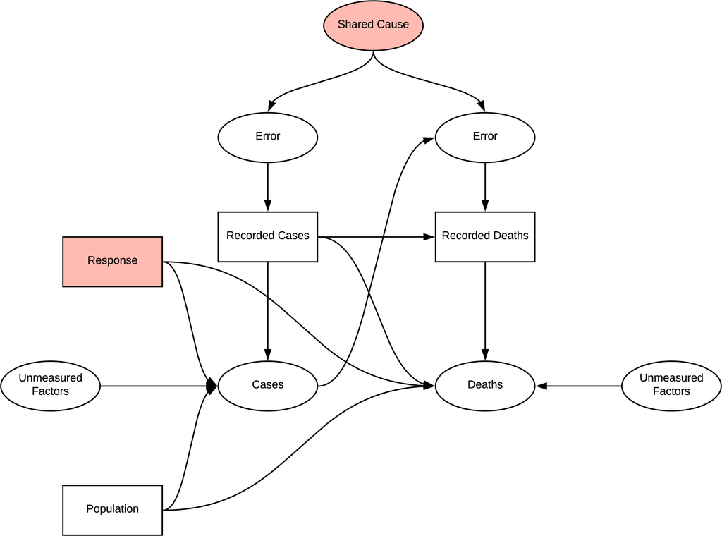

DAG

## Country Based Age Influence

When investigating the effect of age on deaths, conditioning age on higher values opens up the oppourtunity to confounding from common cause. Previously identified measurement bias is consistent.

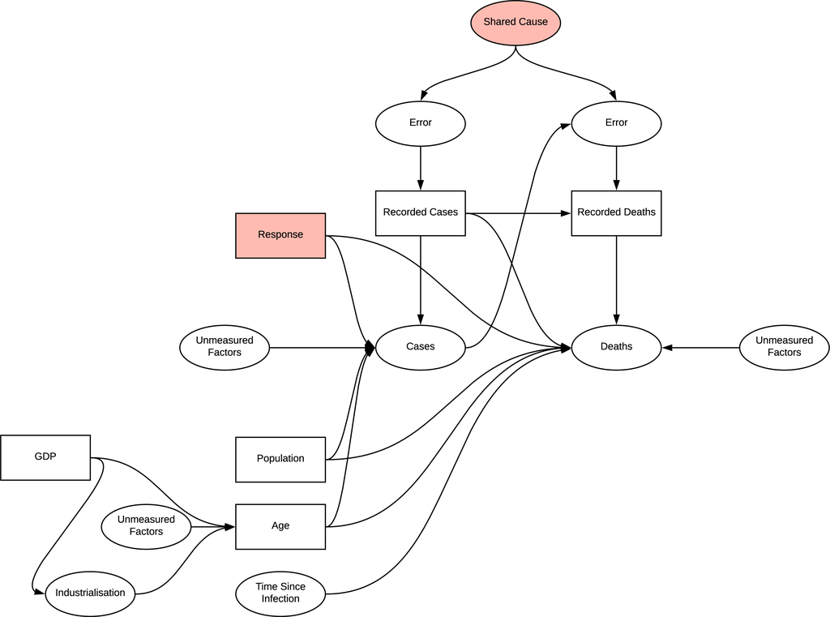

DAG

## Patient Case Based Analysis

In verifying the reason for using this dataset we instead identify two potential shared causes for error inducing measurement bias; disclosure and time since first case. Additonally as this research in focused on patient data, the location variable is introduced, a common cause of many of the observations. It is identified that we can condition on this variable with USA and observe changes in distributions, however the research did not utilise this in regression. The direction of the graph becomes quite complex with the introduction of chronic disease, we also intorduce another source of differntial dependent error. In determining if there is a connection between chronic disease and particular symptons, conditoning symptoms opens the collider inducing a variety of selection bias, age appears to act as a condfounder.

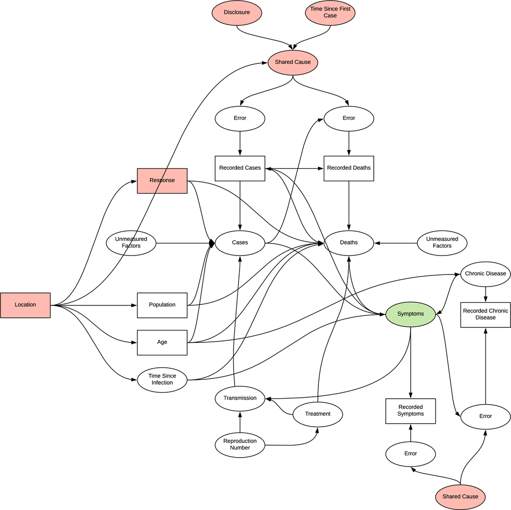

DAG

## Factors and Effectiveness

All the factor analysis introduce selection bias as they select for varying conditions of outcome variables or deaths, in addition to the other bias’s observed previously.

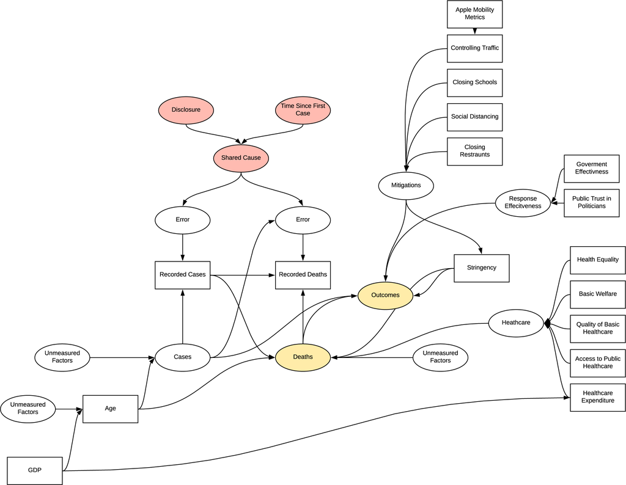

DAG

## Time Varying Treatment

In both the patient based and repsone investigations, time varying treament bias is introduced into the model, the complexity in displaying this prevents visualisation. In patient based investigation, the bias is due to the effect of the change in quality of treatment as understanding of the virus improved effecting the the symptoms and observed. In the response investigations, as the response effects both cases and future response we see a similar effect. Dealing with these biases would require implimenting G-methods.

## Full Implied Structure

As is painfully obvious, the implied structure by the research is quite flawed and has many inherent sources of bias. The structure is also exteremly complex developed as the research progressed.

[figure not shown]

DAG

## Data

```r
# COVID OWID
download.file("https://raw.githubusercontent.com/owid/covid-19-data/master/public/data/owid-covid-data.csv", "./data/covid_owid.csv")

# OxCGRT
download.file("https://github.com/OxCGRT/covid-policy-tracker/raw/master/data/OxCGRT_latest.csv", "./data/oxpol.csv")
```

```r
covid <- read.csv("./data/covid_owid.csv")

#available data

names(covid)
```

```
##  [1] "iso_code"                        "continent"
##  [3] "location"                        "date"
##  [5] "total_cases"                     "new_cases"
##  [7] "total_deaths"                    "new_deaths"
##  [9] "total_cases_per_million"         "new_cases_per_million"
## [11] "total_deaths_per_million"        "new_deaths_per_million"
## [13] "total_tests"                     "new_tests"
## [15] "total_tests_per_thousand"        "new_tests_per_thousand"
## [17] "new_tests_smoothed"              "new_tests_smoothed_per_thousand"
## [19] "tests_units"                     "stringency_index"
## [21] "population"                      "population_density"
## [23] "median_age"                      "aged_65_older"
## [25] "aged_70_older"                   "gdp_per_capita"
## [27] "extreme_poverty"                 "cvd_death_rate"
## [29] "diabetes_prevalence"             "female_smokers"
## [31] "male_smokers"                    "handwashing_facilities"
## [33] "hospital_beds_per_thousand"      "life_expectancy"
```

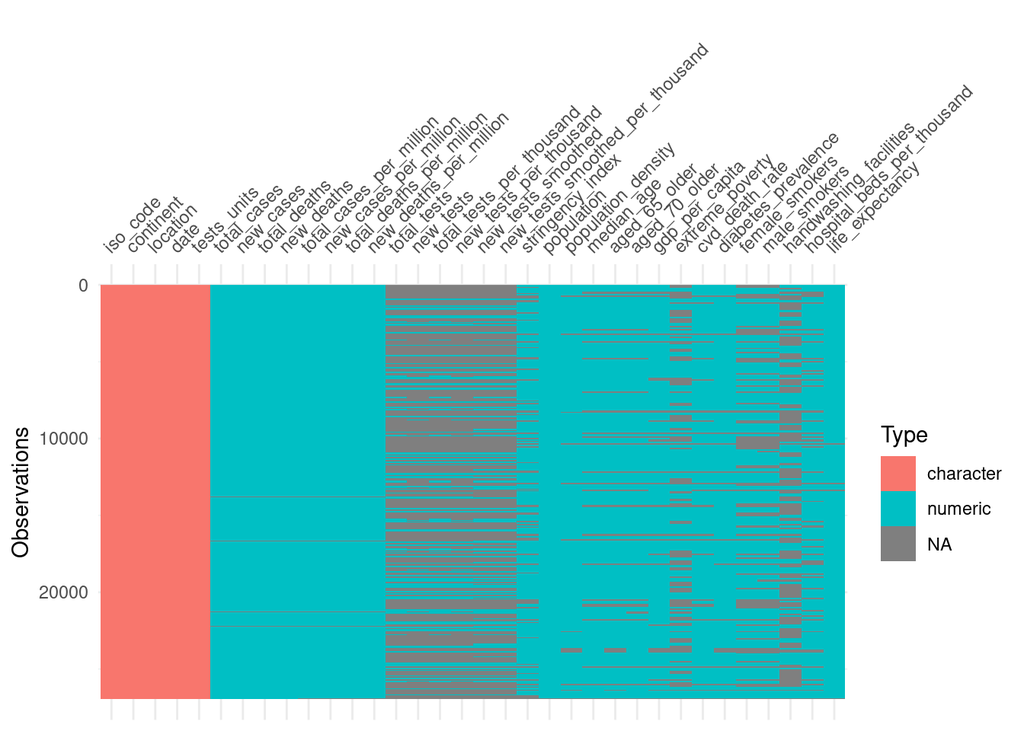

```r
#visualise missing data

vis_dat(covid, warn_large_data = FALSE)
```

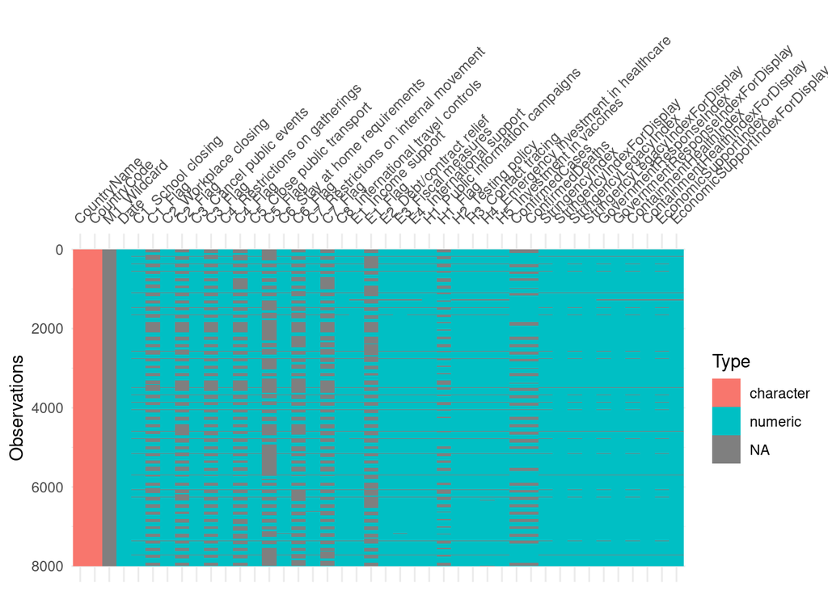

```r
oxpol <- read_csv("./data/oxpol.csv")
vis_dat(oxpol[1:8000,], warn_large_data = FALSE)
```

*COVID OWID Transformations*

```r
coviddata$month <- lubridate::month(coviddata$date, label = TRUE, abbr = TRUE)
coviddata$week <- lubridate::week(coviddata$date)

coviddata_sumweek <- coviddata %>%
  group_by(iso_code, week) %>%
  summarise(
            week_start = first(date),
            week_end = last(date),
            new_cases = sum(new_cases),
            new_deaths = sum(new_deaths),
            new_cases_per_million = sum(new_cases_per_million),
            new_deaths_per_million = sum(new_deaths_per_million),
            new_tests = sum(new_tests),
            new_tests_per_thousand = sum(new_tests_per_thousand),
            )

join <- coviddata %>%
  select(iso_code, location, week_end = date, total_cases, total_deaths, total_cases_per_million, total_deaths_per_million, total_tests)

coviddata_sumweek<- merge(coviddata_sumweek, join, by = c("iso_code", "week_end"))
```

### Directed Acyclic Graph (DAG)

The intial DAG presented is a construct of latent variables that can reasonably be derived from the data available, to construct this dag we create Assumption 1. Within the intial DAG all observerd variables other than the outcome variable are only associated with a single latent variable. This implies we can ignore the observed variables and focus solely on the latent variables when evaluating the DAG for bias.